# Cohort Assembly

Author

Tyler Tong

Published

July 15, 2026

# 1 Load packages

```r
library(tidyverse)
library(readr)
library(gt)
library(purrr)
library(janitor)
```

# 2 Load datasets

```r
DATA_PATH = "/Users/tt/AiReadi/AiReadiSummer2026"
mini_path <- paste0(
  DATA_PATH,
  "/Data/mini"
)
full_path <- paste0(
  DATA_PATH,
  "/Data/full"
)
```

```r
participants <- read_tsv(
  file.path(mini_path, "participants.tsv"),
  show_col_types = FALSE)
cgm_manifest <- read_tsv(
  file.path(mini_path, "cgm.tsv"),
  show_col_types = FALSE
)
activity_manifest <- read_tsv(
  file.path(mini_path, "activity.tsv"),
  show_col_types = FALSE
)
fullparticipants <-  read_tsv(
  file.path(full_path, "participants.tsv"),
  show_col_types = FALSE)

rename_study_group <- function(x) {
  case_match(
    x,
    "healthy" ~ "healthy",
    "pre_diabetes_lifestyle_controlled" ~ "pre_diabetes",
    "oral_medication_and_or_non_insulin_injectable_medication_controlled" ~ "oral_meds",
    "insulin_dependent" ~ "insulin"
  )
}

participants <- participants |>
  mutate(study_group = rename_study_group(study_group))

fullparticipants <- fullparticipants |>
  mutate(study_group = rename_study_group(study_group))
```

# 3 Cohort Table

```r
# clean data
cgmdata <- cgm_manifest |>
  select(person_id, average_glucose_level_mg_dl)
activitydata <- activity_manifest |>
  select(person_id, average_daily_activity)
```

```r
# join data by person_id
data <- participants |>
  left_join(cgmdata, by = join_by(person_id))
data <- data |>
  left_join(activitydata, by = join_by(person_id))
```

```r
# display
head(data)
```

```
# A tibble: 6 × 17
  person_id clinical_site study_group    age study_visit_date recommended_split
      <dbl> <chr>         <chr>        <dbl> <date>           <chr>
1      1029 UW            pre_diabetes    73 2023-09-07       train
2      1042 UW            healthy         40 2023-10-11       train
3      1046 UW            pre_diabetes    50 2023-10-17       train
4      1054 UW            healthy         71 2023-10-31       train
5      1055 UW            healthy         67 2023-11-01       train
6      1073 UW            insulin         40 2023-11-29       train
# ℹ 11 more variables: cardiac_ecg <lgl>, clinical_data <lgl>,
#   environment <lgl>, retinal_flio <lgl>, retinal_oct <lgl>,
#   retinal_octa <lgl>, retinal_photography <lgl>,
#   wearable_activity_monitor <lgl>, wearable_blood_glucose <lgl>,
#   average_glucose_level_mg_dl <dbl>, average_daily_activity <dbl>
```

# 4 Mini Dataset Analysis

```r
studygroups <- participants |>
  count(study_group)
gt(studygroups)
```

| study_group | n |
| --- | --- |
| healthy | 31 |
| insulin | 6 |
| oral_meds | 33 |
| pre_diabetes | 30 |

```r
participants |>
  janitor::tabyl(clinical_site, study_group) |>
  janitor::adorn_totals(c("row", "col")) |>
  gt::gt()
```

| clinical_site | healthy | insulin | oral_meds | pre_diabetes | Total |
| --- | --- | --- | --- | --- | --- |
| UAB | 9 | 1 | 12 | 8 | 30 |
| UCSD | 8 | 2 | 11 | 14 | 35 |
| UW | 14 | 3 | 10 | 8 | 35 |
| Total | 31 | 6 | 33 | 30 | 100 |

```r
countcgm <- participants |>
  count(wearable_blood_glucose)
countactivity <- participants |>
  count(wearable_activity_monitor)
countclinical <- participants |>
  count(clinical_data)
countcgmwearable <- participants |>
  count(wearable_blood_glucose, wearable_activity_monitor)
countall <- participants |>
  count(wearable_blood_glucose, wearable_activity_monitor, clinical_data)

counts <- transmute(countcgm, cgm = map_dbl(n, 1))
counts <- counts |>
  cross_join(transmute(countactivity, activity = map_dbl(n, 1)))
counts <- counts |>
  cross_join(transmute(countclinical, clinical = map_dbl(n, 1)))
counts <- counts |>
  cross_join(transmute(countcgmwearable, cgmwearable = map_dbl(n, 1)))
counts <- counts |>
  cross_join(transmute(countcgmwearable, cgmactivityclinical = map_dbl(n, 1)))

gt(counts)
```

| cgm | activity | clinical | cgmwearable | cgmactivityclinical |
| --- | --- | --- | --- | --- |
| 100 | 100 | 100 | 100 | 100 |

```r
modality_counts <- participants |>
  select(
    cardiac_ecg,
    clinical_data,
    environment,
    retinal_flio,
    retinal_oct,
    retinal_octa,
    retinal_photography,
    wearable_activity_monitor,
    wearable_blood_glucose
  ) |>
  mutate(across(everything(), as.logical)) |>
  pivot_longer(
    cols = everything(),
    names_to = "Modality",
    values_to = "Is_Available"
  ) |>
  filter(Is_Available == TRUE) |>
  count(Modality, name = "Frequency") |>
  mutate(Modality = fct_reorder(Modality, Frequency))
```

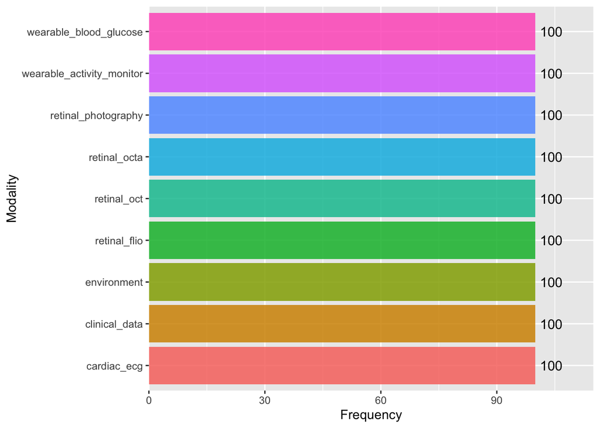

```r
ggplot(modality_counts, aes(x = Frequency, y = Modality, fill = Modality)) +
  geom_col(show.legend = FALSE, alpha = 0.85) +
  geom_text(aes(label = Frequency), hjust = -0.2, size = 4) +
  scale_x_continuous(expand = expansion(mult = c(0, 0.15)))
```

# 5 Mini vs Full

- The mini dataset has 100 participants, while the full dataset has 2,280 participants.
- Both the full and mini have the same study groups and clinical sites.
- The full data set has some gaps in availability, but the mini has full coverage.
- any code written for the mini data set should run the same on the full data set.

# 6 Analysis Cohorts

## 6.1 CGM Cohort

```r
cgmcohort <- fullparticipants |> filter(wearable_blood_glucose)
summary(cgmcohort)
```

```
   person_id      clinical_site     study_group        age
 Min.   :1001   Length   :2245   Length   :2245   Min.   :40.00
 1st Qu.:1575   N.unique :   3   N.unique :   4   1st Qu.:52.00
 Median :4348   N.blank  :   0   N.blank  :   0   Median :61.00
 Mean   :4394   Min.nchar:   2   Min.nchar:   7   Mean   :60.84
 3rd Qu.:7251   Max.nchar:   4   Max.nchar:  12   3rd Qu.:69.00
 Max.   :7818                                     Max.   :94.00
 study_visit_date     recommended_split cardiac_ecg     clinical_data
 Min.   :2023-07-18   Length   :2245    Mode :logical   Mode:logical
 1st Qu.:2024-04-04   N.unique :   3    FALSE:25        TRUE:2245
 Median :2024-08-16   N.blank  :   0    TRUE :2220
 Mean   :2024-08-08   Min.nchar:   3
 3rd Qu.:2024-12-23   Max.nchar:   5
 Max.   :2025-05-01
 environment     retinal_flio    retinal_oct     retinal_octa
 Mode :logical   Mode :logical   Mode :logical   Mode :logical
 FALSE:34        FALSE:419       FALSE:8         FALSE:10
 TRUE :2211      TRUE :1826      TRUE :2237      TRUE :2235



 retinal_photography wearable_activity_monitor wearable_blood_glucose
 Mode :logical       Mode :logical             Mode:logical
 FALSE:1             FALSE:80                  TRUE:2245
 TRUE :2244          TRUE :2165
```

- All participants with CGM data are in this cohort.
- Contains 2,245 participants.
- Represents all 4 study groups.
- Can be used to study how glucose changes in different people who have different conditions, as well as how glucose affects clinical data.
- 80 participants in this cohort do not have wearable data, so this cohort alone cannot be used to study how lifestyle affects glucose for those participants.

## 6.2 CGM + Wearable Cohort

```r
cgmwearablecohort <- fullparticipants |> filter(wearable_blood_glucose, wearable_activity_monitor)
summary(cgmwearablecohort)
```

```
   person_id      clinical_site     study_group        age
 Min.   :1023   Length   :2165   Length   :2165   Min.   :40.00
 1st Qu.:1582   N.unique :   3   N.unique :   4   1st Qu.:52.00
 Median :4354   N.blank  :   0   N.blank  :   0   Median :61.00
 Mean   :4400   Min.nchar:   2   Min.nchar:   7   Mean   :60.76
 3rd Qu.:7269   Max.nchar:   4   Max.nchar:  12   3rd Qu.:69.00
 Max.   :7818                                     Max.   :94.00
 study_visit_date     recommended_split cardiac_ecg     clinical_data
 Min.   :2023-08-30   Length   :2165    Mode :logical   Mode:logical
 1st Qu.:2024-04-18   N.unique :   3    FALSE:22        TRUE:2165
 Median :2024-08-28   N.blank  :   0    TRUE :2143
 Mean   :2024-08-19   Min.nchar:   3
 3rd Qu.:2025-01-06   Max.nchar:   5
 Max.   :2025-05-01
 environment     retinal_flio    retinal_oct     retinal_octa
 Mode :logical   Mode :logical   Mode :logical   Mode :logical
 FALSE:30        FALSE:416       FALSE:8         FALSE:10
 TRUE :2135      TRUE :1749      TRUE :2157      TRUE :2155



 retinal_photography wearable_activity_monitor wearable_blood_glucose
 Mode :logical       Mode:logical              Mode:logical
 FALSE:1             TRUE:2165                 TRUE:2165
 TRUE :2164
```

- Participants who have both CGM and activity data are in this cohort.
- It contains 2,165 participants.
- It can be used to study how glucose responds to lifestyle changes, as well as how that may affect clinical data.
- It may not be used as a representative sample of the real population. Further investigation is need to assess whether this cohort have selection bias towards those who provided activity data.

# 7 Mini Dataset Analysis

```r
data <- participants |> count(study_group)
gt(data)
```

| study_group | n |
| --- | --- |
| healthy | 31 |
| insulin | 6 |
| oral_meds | 33 |
| pre_diabetes | 30 |

```r
data <- participants |> count(clinical_site, study_group)
gt(data, groupname_col = "clinical_site", row_group_as_column = TRUE)
```

|  | study_group | n |
| --- | --- | --- |
| UAB | healthy | 9 |
|  | insulin | 1 |
|  | oral_meds | 12 |
|  | pre_diabetes | 8 |
| UCSD | healthy | 8 |
|  | insulin | 2 |
|  | oral_meds | 11 |
|  | pre_diabetes | 14 |
| UW | healthy | 14 |
|  | insulin | 3 |
|  | oral_meds | 10 |
|  | pre_diabetes | 8 |

```r
countcgm <- participants |> count(wearable_blood_glucose)
countwearable <- participants |> count(wearable_activity_monitor)
countclinical <- participants |> count(clinical_data)
countcgmwearable <- participants |> count(wearable_blood_glucose, wearable_activity_monitor)
countall <- participants |> count(wearable_blood_glucose, wearable_activity_monitor, clinical_data)

counts <- transmute(countcgm, cgm = map_dbl(n, 1))
counts <- counts |> cross_join(transmute(countwearable, wearable = map_dbl(n, 1)))
counts <- counts |> cross_join(transmute(countclinical, clinical = map_dbl(n, 1)))
counts <- counts |> cross_join(transmute(countcgmwearable, cgmwearable = map_dbl(n, 1)))
counts <- counts |> cross_join(transmute(countcgmwearable, cgmwearableclinical = map_dbl(n, 1)))

gt(counts)
```

| cgm | wearable | clinical | cgmwearable | cgmwearableclinical |
| --- | --- | --- | --- | --- |
| 100 | 100 | 100 | 100 | 100 |

```r
modality_counts <- participants |>
  select(
    cardiac_ecg,
    clinical_data,
    environment,
    retinal_flio,
    retinal_oct,
    retinal_octa,
    retinal_photography,
    wearable_activity_monitor,
    wearable_blood_glucose
  ) |>
  mutate(across(everything(), as.logical)) |>
  pivot_longer(
    cols = everything(),
    names_to = "Modality",
    values_to = "Is_Available"
  ) |>
  filter(Is_Available == TRUE) |>
  count(Modality, name = "Frequency") |>
  mutate(Modality = fct_reorder(Modality, Frequency))
```

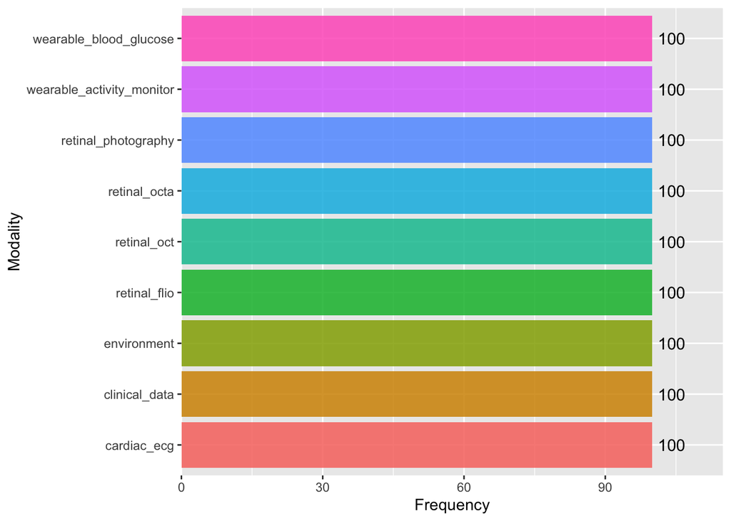

```r
ggplot(modality_counts, aes(x = Frequency, y = Modality, fill = Modality)) +
  geom_col(show.legend = FALSE, alpha = 0.85) +
  geom_text(aes(label = Frequency), hjust = -0.2, size = 4) +
  scale_x_continuous(expand = expansion(mult = c(0, 0.15)))
```

# 8 Mini vs Full

# 9 Analysis Cohorts

## 9.1 CGM Cohort

```r
cgmcohort <- fullparticipants |> filter(wearable_blood_glucose)
summary(cgmcohort)
```

```
   person_id      clinical_site     study_group        age
 Min.   :1001   Length   :2245   Length   :2245   Min.   :40.00
 1st Qu.:1575   N.unique :   3   N.unique :   4   1st Qu.:52.00
 Median :4348   N.blank  :   0   N.blank  :   0   Median :61.00
 Mean   :4394   Min.nchar:   2   Min.nchar:   7   Mean   :60.84
 3rd Qu.:7251   Max.nchar:   4   Max.nchar:  12   3rd Qu.:69.00
 Max.   :7818                                     Max.   :94.00
 study_visit_date     recommended_split cardiac_ecg     clinical_data
 Min.   :2023-07-18   Length   :2245    Mode :logical   Mode:logical
 1st Qu.:2024-04-04   N.unique :   3    FALSE:25        TRUE:2245
 Median :2024-08-16   N.blank  :   0    TRUE :2220
 Mean   :2024-08-08   Min.nchar:   3
 3rd Qu.:2024-12-23   Max.nchar:   5
 Max.   :2025-05-01
 environment     retinal_flio    retinal_oct     retinal_octa
 Mode :logical   Mode :logical   Mode :logical   Mode :logical
 FALSE:34        FALSE:419       FALSE:8         FALSE:10
 TRUE :2211      TRUE :1826      TRUE :2237      TRUE :2235



 retinal_photography wearable_activity_monitor wearable_blood_glucose
 Mode :logical       Mode :logical             Mode:logical
 FALSE:1             FALSE:80                  TRUE:2245
 TRUE :2244          TRUE :2165
```

- All participants with CGM data are in this cohort.
- Contains 2245 participants.
- Represents all 4 study groups.
- Can be used to study how glucose changes in different people who have different conditions, as well as how glucose affects clinical data.
- 80 of the participants in this cohort do not have wearable data, so it can’t be used to study how lifestyle affects glucose.

## 9.2 CGM + Wearable Cohort

```r
cgmwearablecohort <- fullparticipants |> filter(wearable_blood_glucose, wearable_activity_monitor)
summary(cgmwearablecohort)
```

```
   person_id      clinical_site     study_group        age
 Min.   :1023   Length   :2165   Length   :2165   Min.   :40.00
 1st Qu.:1582   N.unique :   3   N.unique :   4   1st Qu.:52.00
 Median :4354   N.blank  :   0   N.blank  :   0   Median :61.00
 Mean   :4400   Min.nchar:   2   Min.nchar:   7   Mean   :60.76
 3rd Qu.:7269   Max.nchar:   4   Max.nchar:  12   3rd Qu.:69.00
 Max.   :7818                                     Max.   :94.00
 study_visit_date     recommended_split cardiac_ecg     clinical_data
 Min.   :2023-08-30   Length   :2165    Mode :logical   Mode:logical
 1st Qu.:2024-04-18   N.unique :   3    FALSE:22        TRUE:2165
 Median :2024-08-28   N.blank  :   0    TRUE :2143
 Mean   :2024-08-19   Min.nchar:   3
 3rd Qu.:2025-01-06   Max.nchar:   5
 Max.   :2025-05-01
 environment     retinal_flio    retinal_oct     retinal_octa
 Mode :logical   Mode :logical   Mode :logical   Mode :logical
 FALSE:30        FALSE:416       FALSE:8         FALSE:10
 TRUE :2135      TRUE :1749      TRUE :2157      TRUE :2155



 retinal_photography wearable_activity_monitor wearable_blood_glucose
 Mode :logical       Mode:logical              Mode:logical
 FALSE:1             TRUE:2165                 TRUE:2165
 TRUE :2164
```

- Participants who have CGM and wearable data are in this cohort.
- Contains 2165 participants.
- Can be used to study how glucose responds to lifestyle changes, as well as how that may affect clinical data.
- Cannot be used as a representative sample of the real population, as it may have selection bias towards those who provided wearable data.